# act_report

## Report: act_report

- Create a **250-word-minimum written report** called "act_report.pdf" or "act_report.html" that communicates the insights and displays the visualization(s) produced from your wrangled data. This is to be framed as an external document, like a blog post or magazine article, for example.

## Analysis Overview

After Creating the Final output we Have now the Below Data from We Rate Dogs Tweets

|  | Unnamed: 0 | key_0 | tweet_id | in_reply_to_status_id_x | in_reply_to_user_id_x | timestamp | source_x | text | retweeted_status_id | retweeted_status_user_id | ... | contributors | is_quote_status | favorite_count | favorited | possibly_sensitive | possibly_sensitive_appealable | lang | quoted_status_id | quoted_status | rating_perc |
| --- | --- | --- | --- | --- | --- | --- | --- | --- | --- | --- | --- | --- | --- | --- | --- | --- | --- | --- | --- | --- | --- |
| 0 | 0 | 892177421306343426 | 892177421306343426 | NaN | NaN | 2017-08-01 00:17:27+00:00 | <a href="http://twitter.com/download/iphone" r... | This is Tilly. She's just checking pup on you.... | NaN | NaN | ... | NaN | False | 33819 | False | False | False | en | NaN | NaN | 1.0 |
| 1 | 1 | 891815181378084864 | 891815181378084864 | NaN | NaN | 2017-07-31 00:18:03+00:00 | <a href="http://twitter.com/download/iphone" r... | This is Archie. He is a rare Norwegian Pouncin... | NaN | NaN | ... | NaN | False | 25461 | False | False | False | en | NaN | NaN | 1.0 |
| 2 | 2 | 891689557279858688 | 891689557279858688 | NaN | NaN | 2017-07-30 15:58:51+00:00 | <a href="http://twitter.com/download/iphone" r... | This is Darla. She commenced a snooze mid meal... | NaN | NaN | ... | NaN | False | 42908 | False | False | False | en | NaN | NaN | 1.0 |
| 3 | 3 | 891327558926688256 | 891327558926688256 | NaN | NaN | 2017-07-29 16:00:24+00:00 | <a href="http://twitter.com/download/iphone" r... | This is Franklin. He would like you to stop ca... | NaN | NaN | ... | NaN | False | 41048 | False | False | False | en | NaN | NaN | 1.0 |
| 4 | 4 | 891087950875897856 | 891087950875897856 | NaN | NaN | 2017-07-29 00:08:17+00:00 | <a href="http://twitter.com/download/iphone" r... | Here we have a majestic great white breaching ... | NaN | NaN | ... | NaN | False | 20562 | False | False | False | en | NaN | NaN | 1.0 |
| 5 | 5 | 890971913173991426 | 890971913173991426 | NaN | NaN | 2017-07-28 16:27:12+00:00 | <a href="http://twitter.com/download/iphone" r... | Meet Jax. He enjoys ice cream so much he gets ... | NaN | NaN | ... | NaN | False | 12041 | False | False | False | en | NaN | NaN | 1.0 |
| 6 | 6 | 890729181411237888 | 890729181411237888 | NaN | NaN | 2017-07-28 00:22:40+00:00 | <a href="http://twitter.com/download/iphone" r... | When you watch your owner call another dog a g... | NaN | NaN | ... | NaN | False | 56848 | False | False | False | en | NaN | NaN | 1.0 |
| 7 | 7 | 890609185150312448 | 890609185150312448 | NaN | NaN | 2017-07-27 16:25:51+00:00 | <a href="http://twitter.com/download/iphone" r... | This is Zoey. She doesn't want to be one of th... | NaN | NaN | ... | NaN | False | 28226 | False | False | False | en | NaN | NaN | 1.0 |
| 8 | 8 | 890240255349198849 | 890240255349198849 | NaN | NaN | 2017-07-26 15:59:51+00:00 | <a href="http://twitter.com/download/iphone" r... | This is Cassie. She is a college pup. Studying... | NaN | NaN | ... | NaN | False | 32467 | False | False | False | en | NaN | NaN | 1.0 |
| 9 | 9 | 890006608113172480 | 890006608113172480 | NaN | NaN | 2017-07-26 00:31:25+00:00 | <a href="http://twitter.com/download/iphone" r... | This is Koda. He is a South Australian decksha... | NaN | NaN | ... | NaN | False | 31166 | False | False | False | en | NaN | NaN | 1.0 |

10 rows × 52 columns

We Have analyzed the above Data and got the below insightes

   Above insights was driven based on the most columns which make a good statistical output from the data

##### 1. Dog types are distributed. as None with 84% then pupper with 10.22% then doggo with 3.30%

I've created count based on all the dog types available in the dataset and got that the heighest 3 types are

1. Dogs with no type with around 84% of the data
2. Pupper dogs are most popular with 10.22%
3. Doggo dogs are the second most popular type with 3.30%.

##### 3. Most of the rates comes with 100% for almost 83.29

I've created new column for rating percentage to get the get the heighest rating and we got the below

1. Heighest rating is 900%
2. most of the data (83.29%) have 100% rating

Below are some graphs that dexcribe the above insights

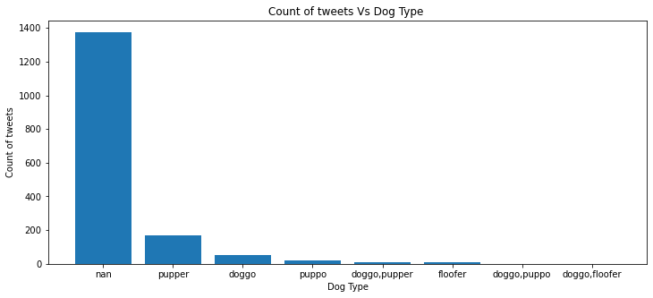

In the below Graph we can see that big portion of tweets has only 1 image

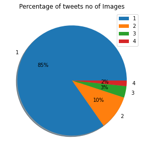

Below Graph shows that most of the retweets are with 100%

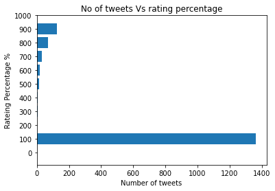